# ETC3250/5250 Introduction to Machine Learning

Week 9: K-means and hierarchical clustering

Jack Jewson

Jack.Jewson@monash.edu

Department of Econometrics and Business Statistics

## Overview

We will cover:

- Defining distance measure
- $k$-means algorithm
- Hierarchical algorithms
- Making and using dendrograms

## Supervised vs Unsupervised Learning

**Classification**

- Given response $\{y_i\}_{i=1}^n$ with each $y_i \in \{1, \ldots, K\}$ and predictors $\{x_i\}_{i=1}^n$ with each $x_i\in\mathbb{R}^p$
- Classification seeks to learn the relationship $x\mapsto y$
- Supervised learning as we are given $y$’s

**Clustering**

- Given predictors $\{x_i\}_{i=1}^n$ with each $x_i\in\mathbb{R}^p$
- Clustering tries to learn $y_i\in \{1, \ldots, K\}$ for each observation $i = 1, \ldots, n$
- i.e. learn about unlabeled groups in the data
- Unsupervised learning as we are not given the $y$’s
- Similar idea to PCA,
  - Have $x\in\mathbb{R}^p$ and we want to learn a lower dimensional representation $z\in\mathbb{R}^k$
  - We were not given these $z$’s

## Cluster analysis

- The aim of cluster analysis is to group cases (objects) according to their similarity on the variables.
- It is also often called unsupervised classification, meaning that classification is the ultimate goal, but the classes (groups) are not known ahead of time.
- Cluster analysis works by grouping close observations together
- To determine closeness we start with measuring the interpoint distances.

## Cluster these!

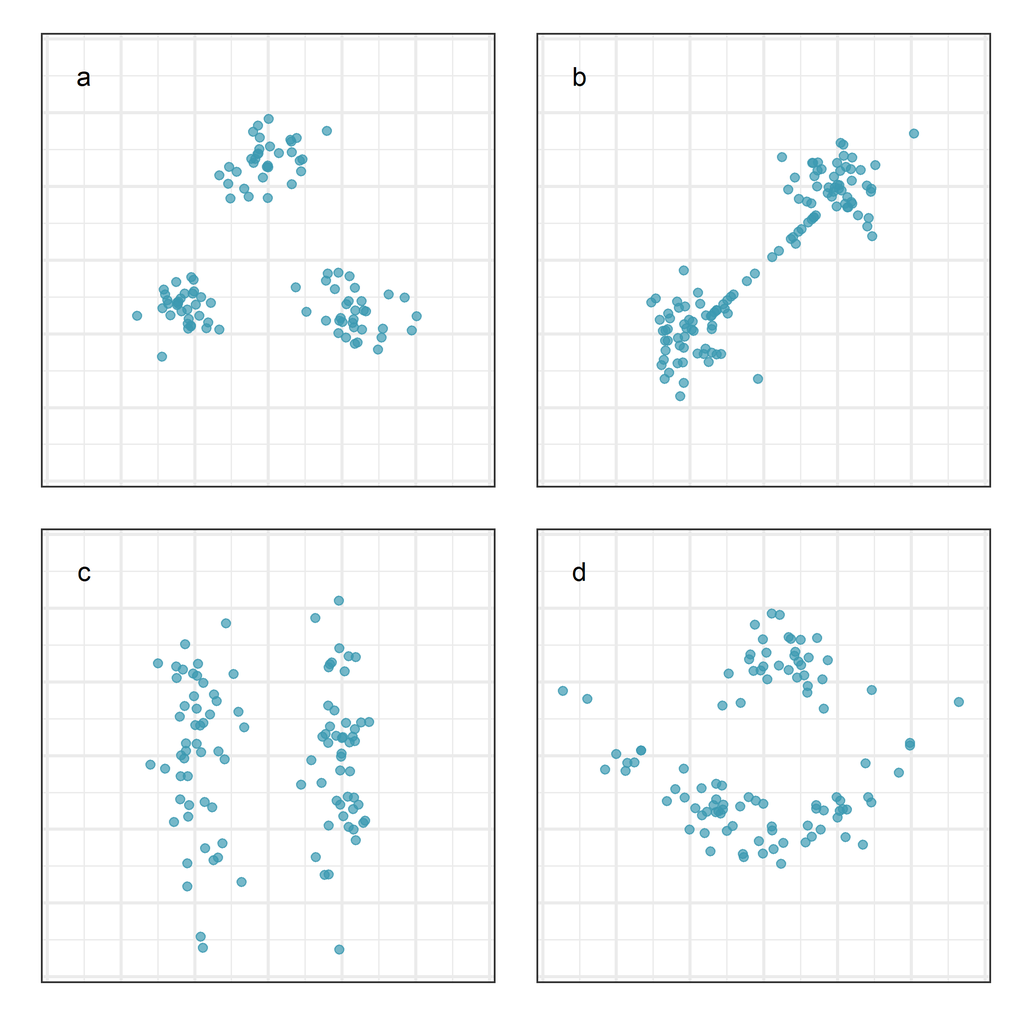

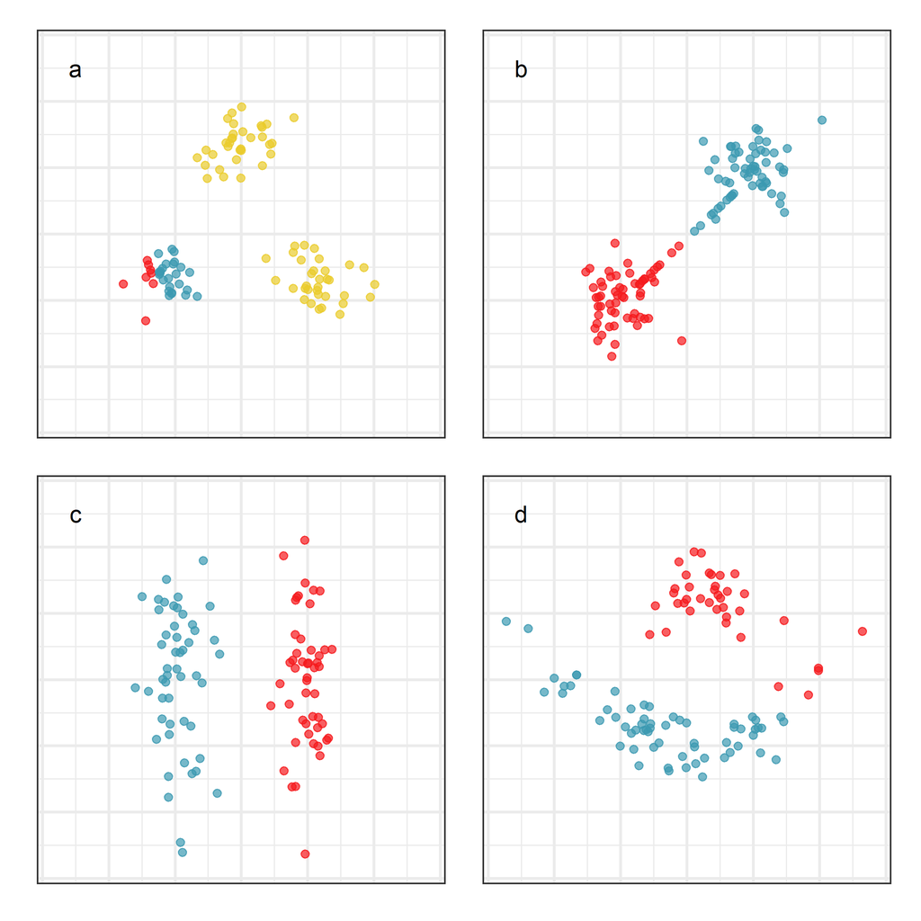

It’s *easy* if we can see the clusters, but what an algorithm sees might be quite different.

## Seeing the clusters using spin-and-brush

```r
library(detourr)
set.seed(645)
detour(p_std[,2:5],
       tour_aes(projection = bl:bm)) |>
       tour_path(grand_tour(2), fps = 60,
                 max_bases=40) |>
       show_scatter(alpha = 0.7,
                    axes = FALSE)
```

If you see a cluster in any projection of the data then it exists in high dimensions

You have enough clusters when you don’t see any more groups break out

Can use to see if your clusters agree with an algorithm’s

## How do you measure “close”?

## Common interpoint distance measures

Let $X_A=(x_{a1}, x_{a2}, ..., x_{ap})$ and $X_B=(x_{b1}, x_{b2}, ..., x_{bp})$.

Euclidean

$$\begin{align*}
d_{EUC}(X_A, X_B) &= \sqrt{\sum_{j=1}^p (x_{aj}-x_{bj})^2} &\\
&= \sqrt{((X_A-X_B)^\top (X_A-X_B))}&
\end{align*}$$

Other distance metrics

- Mahalanobis (or statistical) distance: $\sqrt{((X_A-X_B)^\top S^{-1} (X_A-X_B))}$
- Manhattan: $\sum_{j=1}^p|(X_{aj}-X_{bj})|$
- Minkowski: $(\sum_{j=1}^p|(X_{aj}-X_{bj})|^m)^{1/m}$

Count data

- Canberra: $\frac{1}{n_z}\sum_{j=1}^p\frac{X_{aj}-X_{bj}}{X_{aj}+X_{bj}}$
- Bray-Curtis: $\frac{\sum_{j=1}^p|X_{aj}-X_{bj}|}{\sum_{j=1}^p(X_{aj}+X_{bj})}$

Categorical variables

- 1- simple matching coefficient: $1-(\text{#matches})/p$
- Convert to dummy variables, and use Euclidean distance

Mixed variable types

- Gower’s distance

Other

- Hamming: all binary variables, number of variables at which values are different.
- Cosine: $\frac{\sum_{j=1}^p X_{aj}X_{bj}}{||X_a|| ||X_b||}$ (How does this compare to a calculation of correlation??)

## Mahalanobis distance

Mahalanobis (or statistical) distance: $\sqrt{((X_A-X_B)^\top S^{-1} (X_A-X_B))}$

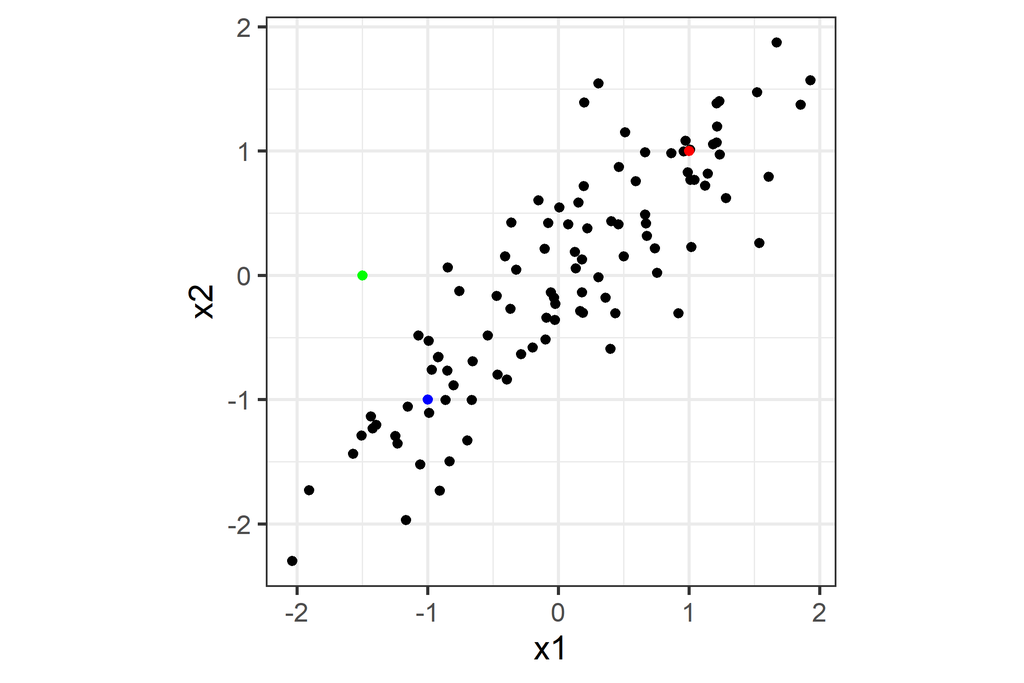

- The green and blue are closest in Euclidean distance
- But the red and blue are closest in Mahalanobis distance
- as they are both more consistent with the structure of the data

## Distance calculations

```
   V1  V2  V3  V4 point
1 7.3 7.6 7.7 8.0    a1
2 7.4 7.2 7.3 7.2    a2
3 4.1 4.6 4.6 4.8    a3
```

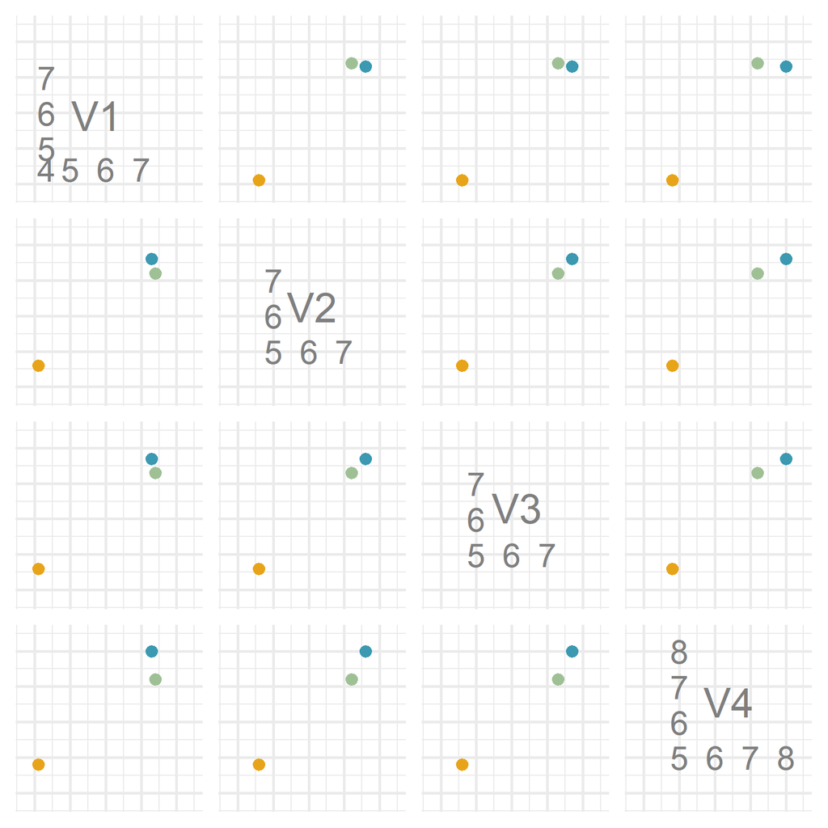

Compute Euclidean distance between $a_1$ and $a_2$.

```r
(x[1,1:4] - x[2,1:4])^2
```

```
    V1   V2   V3   V4
1 0.01 0.16 0.16 0.64
```

```r
sum((x[1,1:4] - x[2,1:4])^2)
```

```
[1] 0.97
```

```r
sqrt(sum((x[1,1:4] - x[2,1:4])^2))
```

```
[1] 0.98
```

between $a_1$ and $a_3$

```r
sqrt(sum((x[1,1:4] - x[3,1:4])^2))
```

```
[1] 6.3
```

🔑 Standardise your variables!!!!

## Distance calculations

```
   V1  V2  V3  V4 point
1 7.3 7.6 7.7 8.0    a1
2 7.4 7.2 7.3 7.2    a2
3 4.1 4.6 4.6 4.8    a3
```

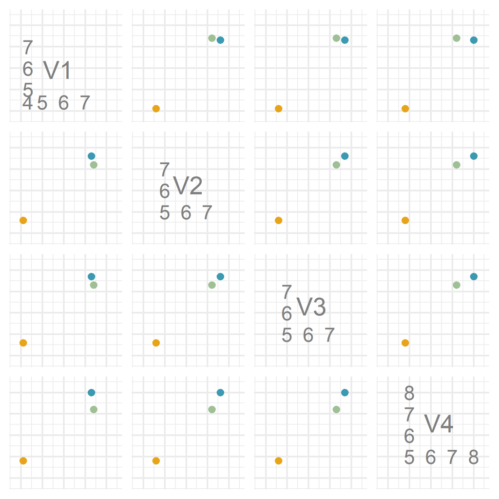

Could you compute a correlation distance? $d_{cor}(A, B) = 1-|r(x_A, x_B)|$.

Where $r(x_1, x_2)$ is the correlation between vectors $x_1$ and $x_2$

Is $a_1$ close to $a_3$ than $a_2$?

```r
1 - abs(cor(t(x[1:2,1:4]))[1,2])
```

```
[1] 0.22
```

```r
1 - abs(cor(t(x[c(1, 3),1:4]))[1,2])
```

```
[1] 0.053
```

## Basic rules of a distance metric

Anything can be a distance if it follows these rules:

1. $d(A, B) \geq 0$
2. $d(A, A) = 0$
3. $d(A, B) = d(B, A)$
4. Metric dissimilarity satisfies $d(A, B) \leq d(A, C) + d(C, B)$

## Dissimilarity vs similarity

- Distance is a **dissimilarity** measure because small means close and large means far.
- Correlation is a **similarity** measure because the larger the value the closer the objects. It can be converted to a dissimilarity with a transformation (hence why we took $d_{cor}(A, B) = 1-|r(x_A, x_B)|$.

## $k$-means clustering

## k-means clustering - algorithm (1/8)

This is an iterative clustering algorithm.

To use it the number of clusters, $k$, must be decided first.

1. Initialize by either
- partitioning the data into k groups, and compute the $k$ group means or
- an initial set of $k$ points as the first estimate of the cluster means (seed points).
2. Loop over all observations reassigning them to the group with the closest mean.
3. Recompute group means.
4. Iterate steps 2 and 3 (estimating the cluster means and reassigning each observation to the cluster with the closest mean) until convergence.

Convergence means that the cluster means don’t change from one iteration to the next

[Thean C. Lim’s blog post](https://theanlim.rbind.io/post/clustering-k-means-k-means-and-gganimate/)

**Do not confuse with k-nearest neighbours!**

## k-means clustering - algorithm (2/8)

| lbl | x1 | x2 |
| --- | --- | --- |
| a | 16 | 4 |
| b | 19 | 8 |
| c | 14 | 4 |
| d | 19 | 9 |
| e | 10 | 21 |
| f | 7 | 19 |
| g | 1 | 20 |
| h | 2 | 15 |
| i | 3 | 6 |
| j | 3 | 7 |
| k | 6 | 2 |
| l | 6 | 5 |

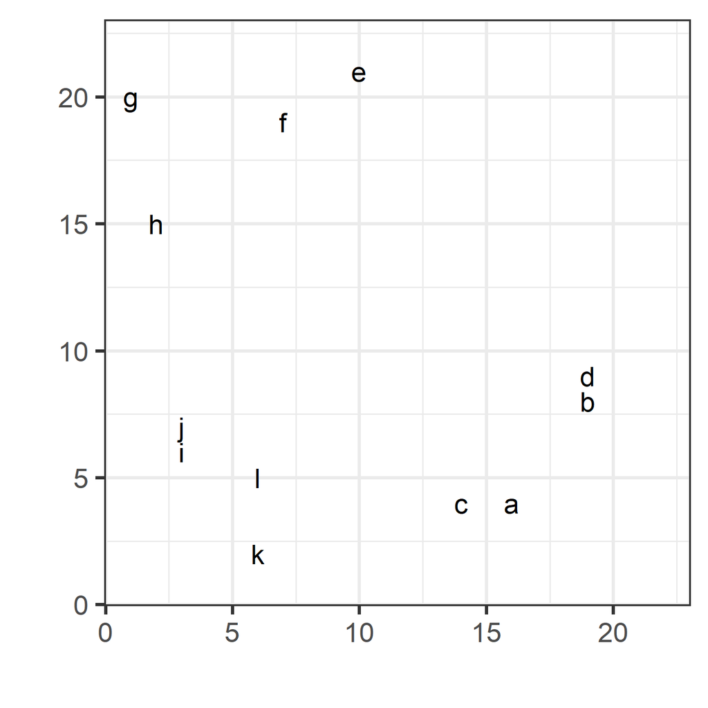

## k-means clustering - algorithm (3/8)

Select $k=2$,

and set initial seed means  
$\bar{x}_1=$ (10, 11) , $\bar{x}_2=$ (11, 9)

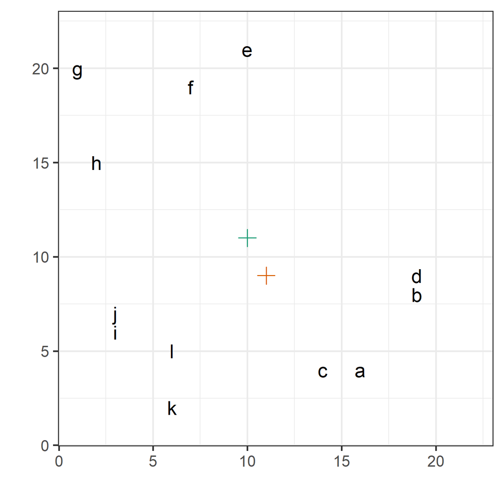

## k-means clustering - algorithm (4/8)

Compute distances $(d_1, d_2)$ between each observation and each mean,

$\bar{x}_1=$ (10, 11) , $\bar{x}_2=$ (11, 9)

| lbl | x1 | x2 | d1 | d2 |
| --- | --- | --- | --- | --- |
| a | 16 | 4 | 9.2 | 7.1 |
| b | 19 | 8 | 9.5 | 8.1 |
| c | 14 | 4 | 8.1 | 5.8 |
| d | 19 | 9 | 9.2 | 8.0 |
| e | 10 | 21 | 10.0 | 12.0 |
| f | 7 | 19 | 8.5 | 10.8 |
| g | 1 | 20 | 12.7 | 14.9 |
| h | 2 | 15 | 8.9 | 10.8 |
| i | 3 | 6 | 8.6 | 8.5 |
| j | 3 | 7 | 8.1 | 8.2 |
| k | 6 | 2 | 9.8 | 8.6 |
| l | 6 | 5 | 7.2 | 6.4 |

## k-means clustering - algorithm (5/8)

Assign each observation to a cluster, based on which mean is closest.

| lbl | x1 | x2 | d1 | d2 | cl |
| --- | --- | --- | --- | --- | --- |
| a | 16 | 4 | 9.2 | 7.1 | 2 |
| b | 19 | 8 | 9.5 | 8.1 | 2 |
| c | 14 | 4 | 8.1 | 5.8 | 2 |
| d | 19 | 9 | 9.2 | 8.0 | 2 |
| e | 10 | 21 | 10.0 | 12.0 | 1 |
| f | 7 | 19 | 8.5 | 10.8 | 1 |
| g | 1 | 20 | 12.7 | 14.9 | 1 |
| h | 2 | 15 | 8.9 | 10.8 | 1 |
| i | 3 | 6 | 8.6 | 8.5 | 2 |
| j | 3 | 7 | 8.1 | 8.2 | 1 |
| k | 6 | 2 | 9.8 | 8.6 | 2 |
| l | 6 | 5 | 7.2 | 6.4 | 2 |

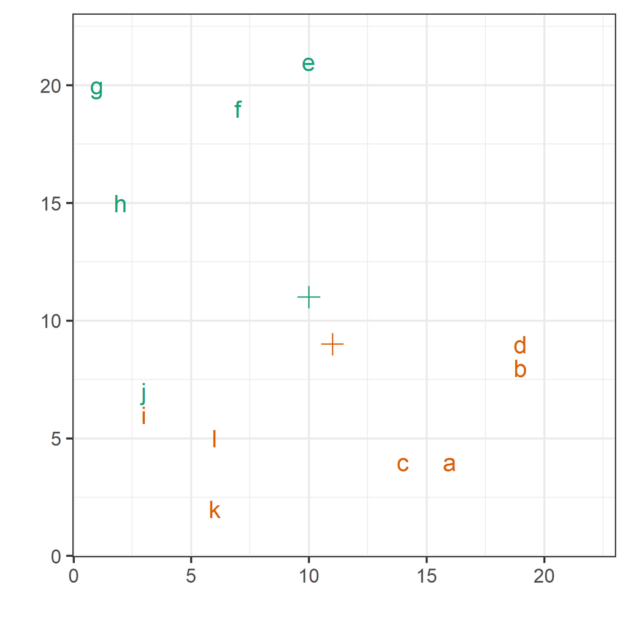

## k-means clustering - algorithm (6/8)

Recompute means, and re-assign the cluster membership

$\bar{x}_1=$ (5, 16) , $\bar{x}_2=$ (12, 5)

| lbl | x1 | x2 | d1 | d2 | cl |
| --- | --- | --- | --- | --- | --- |
| a | 16 | 4 | 16.8 | 4.4 | 2 |
| b | 19 | 8 | 16.7 | 7.6 | 2 |
| c | 14 | 4 | 15.6 | 2.6 | 2 |
| d | 19 | 9 | 16.2 | 8.0 | 2 |
| e | 10 | 21 | 7.1 | 15.7 | 1 |
| f | 7 | 19 | 3.5 | 14.4 | 1 |
| g | 1 | 20 | 5.1 | 18.2 | 1 |
| h | 2 | 15 | 3.0 | 13.7 | 1 |
| i | 3 | 6 | 10.5 | 8.9 | 2 |
| j | 3 | 7 | 9.5 | 9.0 | 2 |
| k | 6 | 2 | 14.5 | 6.8 | 2 |
| l | 6 | 5 | 11.5 | 5.9 | 2 |

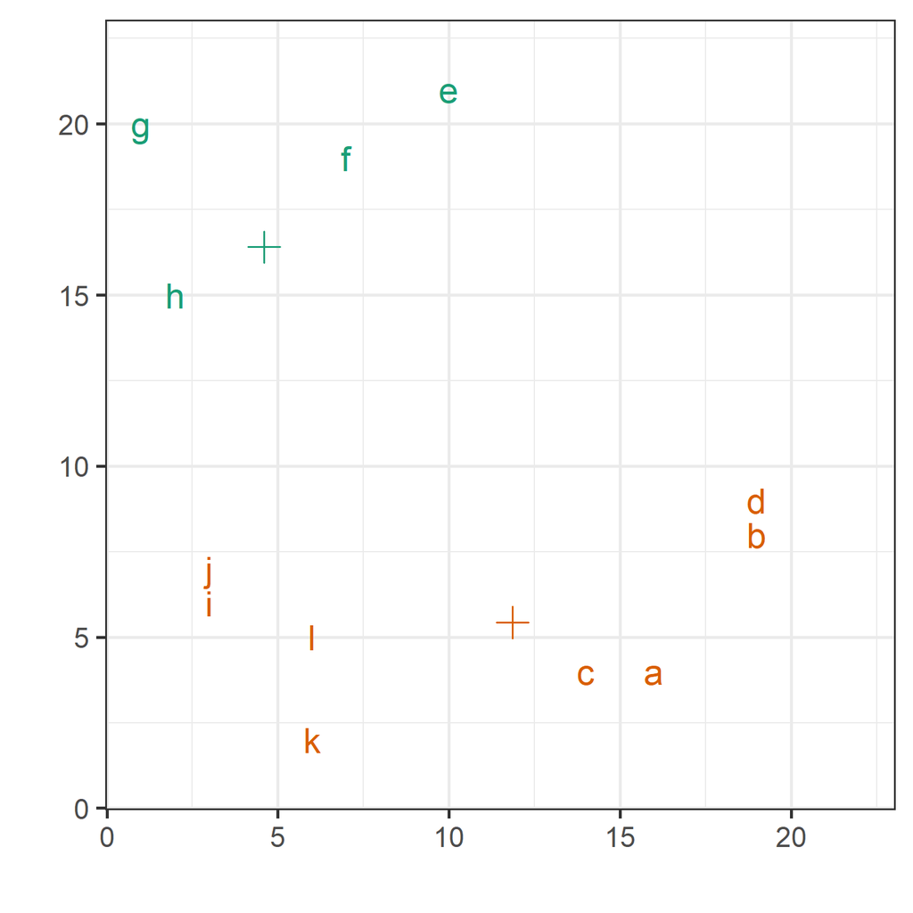

## k-means clustering - algorithm (7/8)

Recompute means, and re-assign the cluster membership

$\bar{x}_1=$ (5, 19) , $\bar{x}_2=$ (11, 6)

| lbl | x1 | x2 | d1 | d2 | cl |
| --- | --- | --- | --- | --- | --- |
| a | 16 | 4 | 18.4 | 5.5 | 2 |
| b | 19 | 8 | 17.7 | 8.6 | 2 |
| c | 14 | 4 | 17.3 | 3.6 | 2 |
| d | 19 | 9 | 17.1 | 8.9 | 2 |
| e | 10 | 21 | 5.5 | 15.4 | 1 |
| f | 7 | 19 | 2.0 | 13.9 | 1 |
| g | 1 | 20 | 4.2 | 17.4 | 1 |
| h | 2 | 15 | 4.8 | 12.8 | 1 |
| i | 3 | 6 | 12.9 | 7.8 | 2 |
| j | 3 | 7 | 11.9 | 7.9 | 2 |
| k | 6 | 2 | 16.8 | 6.0 | 2 |
| l | 6 | 5 | 13.8 | 4.8 | 2 |

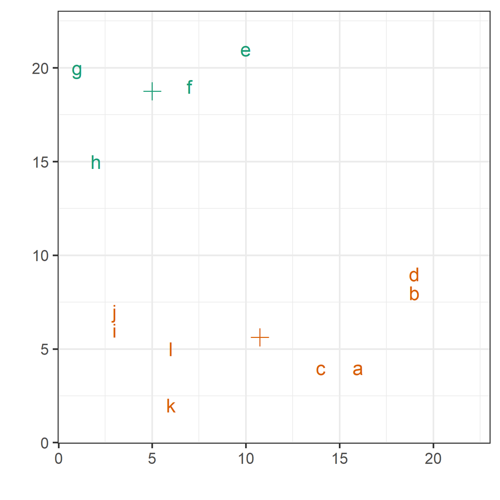

## k-means clustering - algorithm (8/8)

Recompute means, and re-assign the cluster membership

$\bar{x}_1=$ (5, 19) , $\bar{x}_2=$ (11, 6)

The means didn’t change so we have converged

| lbl | x1 | x2 | d1 | d2 | cl |
| --- | --- | --- | --- | --- | --- |
| a | 16 | 4 | 18.4 | 5.5 | 2 |
| b | 19 | 8 | 17.7 | 8.6 | 2 |
| c | 14 | 4 | 17.3 | 3.6 | 2 |
| d | 19 | 9 | 17.1 | 8.9 | 2 |
| e | 10 | 21 | 5.5 | 15.4 | 1 |
| f | 7 | 19 | 2.0 | 13.9 | 1 |
| g | 1 | 20 | 4.2 | 17.4 | 1 |
| h | 2 | 15 | 4.8 | 12.8 | 1 |
| i | 3 | 6 | 12.9 | 7.8 | 2 |
| j | 3 | 7 | 11.9 | 7.9 | 2 |
| k | 6 | 2 | 16.8 | 6.0 | 2 |
| l | 6 | 5 | 13.8 | 4.8 | 2 |

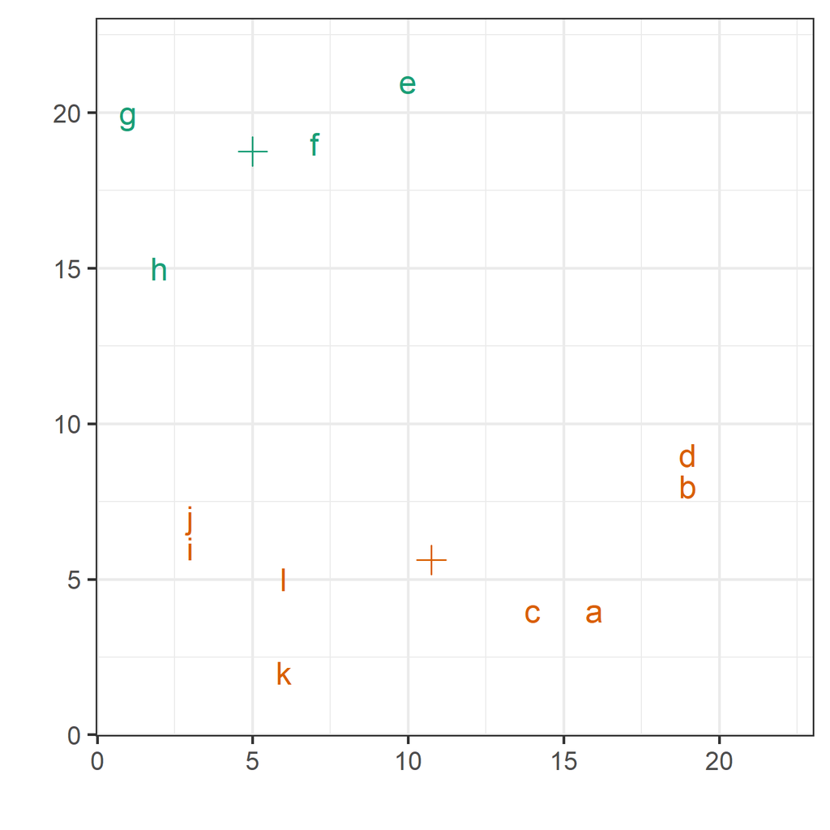

## Example: penguins

- We know there are three clusters, but generally we don’t know this.
- Will $k=3$-means clustering see the clusters that we knoew the data has?
- Fit for various values of $k$. Add cluster label to data.
- Examine solution in plots of the data.
- Compute cluster metrics.
- NOTE: `set.seed()` because results can depend on initialisation.

kmeans

```r
set.seed(712)
p_km3 <- kmeans(p_std[,2:5], 3)
p_std_km <- p_std |>
  mutate(cl = factor(p_km3$cluster))
```

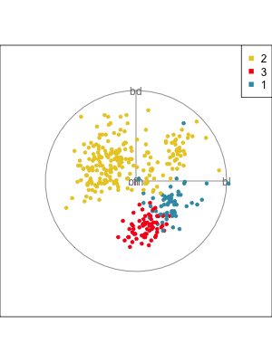

## Choosing $k$ with cluster statistics (1/2)

We want within cluster distance to be small, and between cluster distance to be big

- within.cluster.ss: sum of distances within cluster. Want it to be low, but always drops for each additional cluster so look for large drops.
- WBRatio: average within/average between distances. Want it to be low, but always drops for each additional cluster so look for large drops.
- Hubert Gamma: $\frac{(s^{+} - s^{-})}{(s^{+} + s^{-})}$ where $s^{+}$ is the sum of number of within $<$ between, $s-$ is sum of number within $>$ between. Want this to be high.
- Dunn: ratio of (smallest distance between points from different clusters) to (maximum distance of points within any cluster). Want this to be high.
- Calinski-Harabasz Index: $\frac{\sum_{i=1}^p B_{ii}/(k-1)}{\sum_{i=1}^p W_{ii}/(n-k)}$. Want this to be high.

## Choosing $k$ with cluster statistics (2/2)

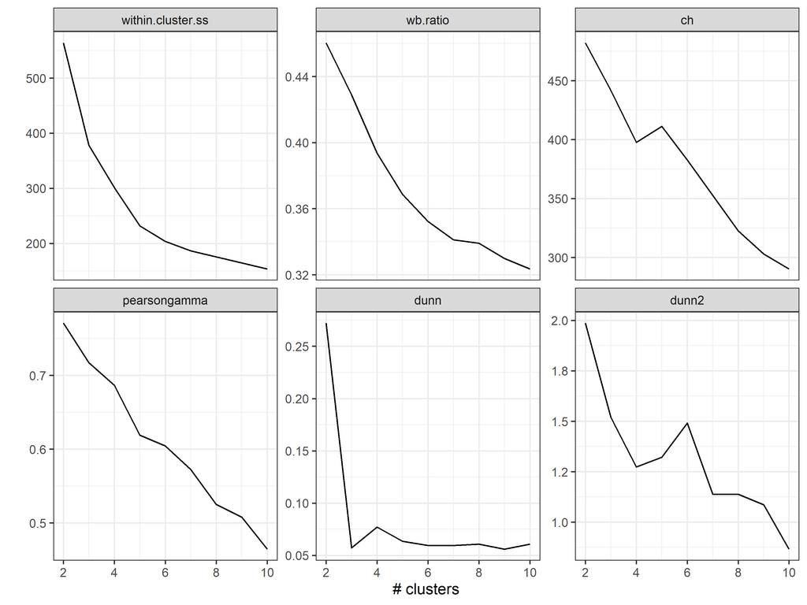

Maybe there are subspecies of each penguin…

- Results are inconclusive. No agreement between metrics.
- Not unusual. Stay tuned for nuisance variables and observations.

## Hierarchical clustering

## Hierarchical clustering 1/5

- Agglomeration: Begin with all observations in singleton clusters. Sequentially join points into clusters, until all are in one cluster.
- Divisive: Begin with all observations in one cluster, and sequentially divide until all observations are in singleton clusters.
- Produces a tree diagram illustrating the process, called a dendrogram.

## Hierarchical clustering 2/5

Don’t need to decide on the number of clusters ahead of time

$n\times n$ distance matrix - dist

```r
d <- as.matrix(round(dist(df[,2:3], diag=TRUE, upper=TRUE),1))
```

|  | a | b | c | d | e | f | g | h | i | j | k | l |
| --- | --- | --- | --- | --- | --- | --- | --- | --- | --- | --- | --- | --- |
| a | 0.0 | 5.0 | 2.0 | 5.8 | 18.0 | 17.5 | 21.9 | 17.8 | 13.2 | 13.3 | 10.2 | 10.0 |
| b | 5.0 | 0.0 | 6.4 | 1.0 | 15.8 | 16.3 | 21.6 | 18.4 | 16.1 | 16.0 | 14.3 | 13.3 |
| c | 2.0 | 6.4 | 0.0 | 7.1 | 17.5 | 16.6 | 20.6 | 16.3 | 11.2 | 11.4 | 8.2 | 8.1 |
| d | 5.8 | 1.0 | 7.1 | 0.0 | 15.0 | 15.6 | 21.1 | 18.0 | 16.3 | 16.1 | 14.8 | 13.6 |
| e | 18.0 | 15.8 | 17.5 | 15.0 | 0.0 | 3.6 | 9.1 | 10.0 | 16.6 | 15.7 | 19.4 | 16.5 |
| f | 17.5 | 16.3 | 16.6 | 15.6 | 3.6 | 0.0 | 6.1 | 6.4 | 13.6 | 12.6 | 17.0 | 14.0 |
| g | 21.9 | 21.6 | 20.6 | 21.1 | 9.1 | 6.1 | 0.0 | 5.1 | 14.1 | 13.2 | 18.7 | 15.8 |
| h | 17.8 | 18.4 | 16.3 | 18.0 | 10.0 | 6.4 | 5.1 | 0.0 | 9.1 | 8.1 | 13.6 | 10.8 |
| i | 13.2 | 16.1 | 11.2 | 16.3 | 16.6 | 13.6 | 14.1 | 9.1 | 0.0 | 1.0 | 5.0 | 3.2 |
| j | 13.3 | 16.0 | 11.4 | 16.1 | 15.7 | 12.6 | 13.2 | 8.1 | 1.0 | 0.0 | 5.8 | 3.6 |
| k | 10.2 | 14.3 | 8.2 | 14.8 | 19.4 | 17.0 | 18.7 | 13.6 | 5.0 | 5.8 | 0.0 | 3.0 |
| l | 10.0 | 13.3 | 8.1 | 13.6 | 16.5 | 14.0 | 15.8 | 10.8 | 3.2 | 3.6 | 3.0 | 0.0 |

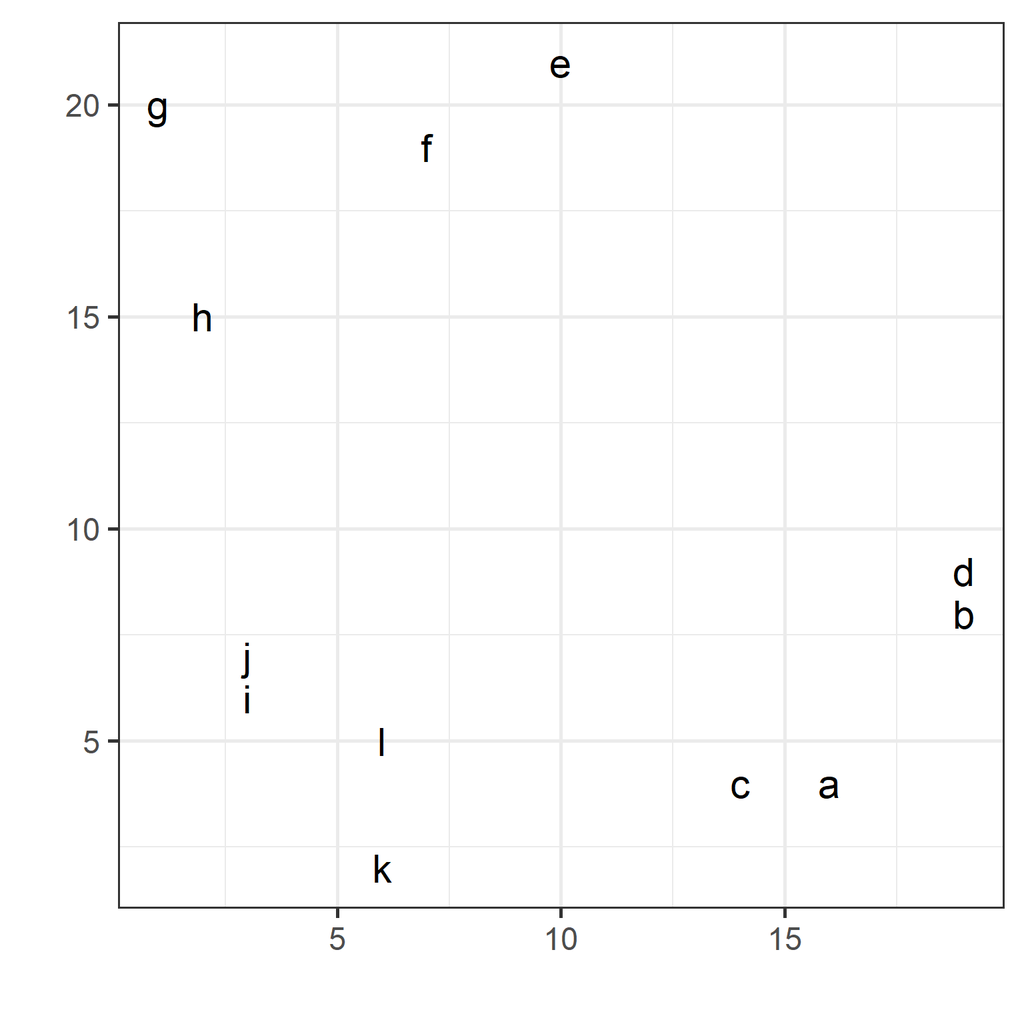

## Hierarchical clustering 3/5

1. Input the pairwise distance between all points
2. Cluster the two closest points together
3. Recalculate distance between the cluster and all of the other observations
4. Repeat 2) and 3) until all of the observations are in the same cluster

## Hierarchical clustering 4/5

Cluster `d` and `b` together and `i` and `j` together at distance 1

|  | b,d | i,j | a | c | e | f | g | h | k | l |
| --- | --- | --- | --- | --- | --- | --- | --- | --- | --- | --- |
| b,d | 0.0 | 16.1 | 5.4 | 6.7 | 15.4 | 15.9 | 21.4 | 18.2 | 14.5 | 13.5 |
| i,j | 16.1 | 0.0 | 13.2 | 11.3 | 16.1 | 13.1 | 13.6 | 8.6 | 5.4 | 3.4 |
| a | 5.4 | 13.2 | 0.0 | 2.0 | 18.0 | 17.5 | 21.9 | 17.8 | 10.2 | 10.0 |
| c | 6.7 | 11.3 | 2.0 | 0.0 | 17.5 | 16.6 | 20.6 | 16.3 | 8.2 | 8.1 |
| e | 15.4 | 16.1 | 18.0 | 17.5 | 0.0 | 3.6 | 9.1 | 10.0 | 19.4 | 16.5 |
| f | 15.9 | 13.1 | 17.5 | 16.6 | 3.6 | 0.0 | 6.1 | 6.4 | 17.0 | 14.0 |
| g | 21.4 | 13.6 | 21.9 | 20.6 | 9.1 | 6.1 | 0.0 | 5.1 | 18.7 | 15.8 |
| h | 18.2 | 8.6 | 17.8 | 16.3 | 10.0 | 6.4 | 5.1 | 0.0 | 13.6 | 10.8 |
| k | 14.5 | 5.4 | 10.2 | 8.2 | 19.4 | 17.0 | 18.7 | 13.6 | 0.0 | 3.0 |
| l | 13.5 | 3.4 | 10.0 | 8.1 | 16.5 | 14.0 | 15.8 | 10.8 | 3.0 | 0.0 |

Then we could cluster `a` and `c` together at distance 2

## Hierarchical clustering 5/5

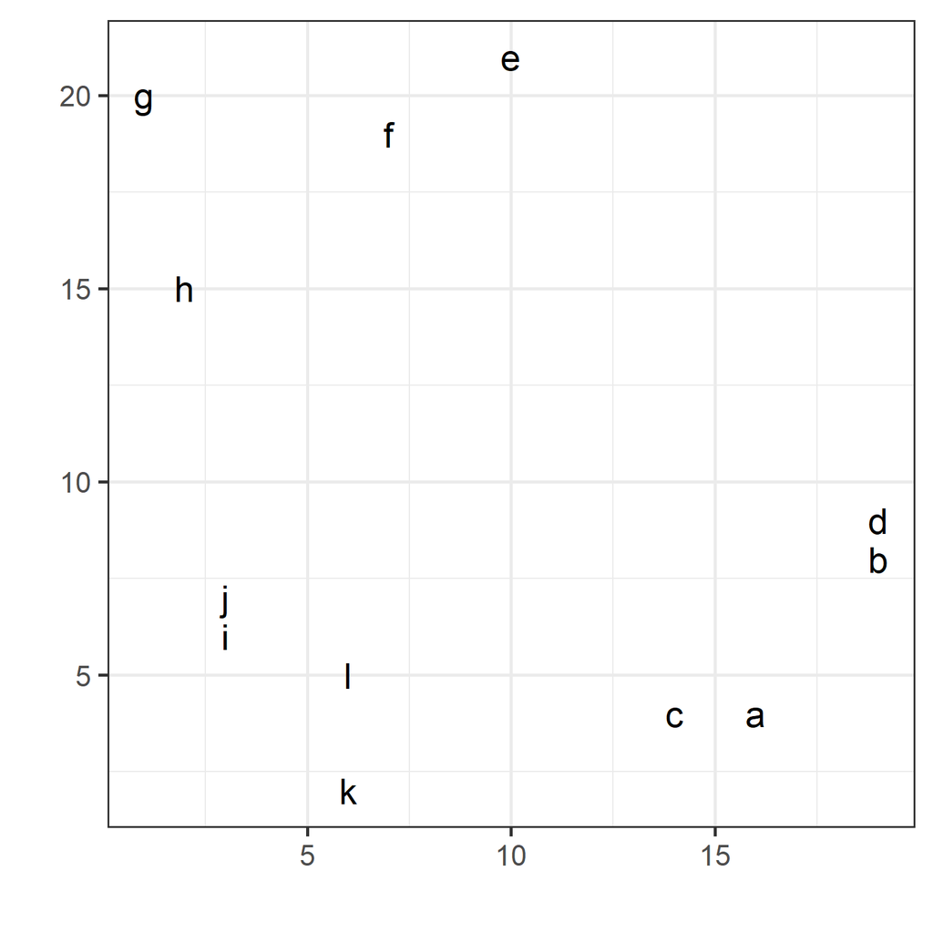

hclust

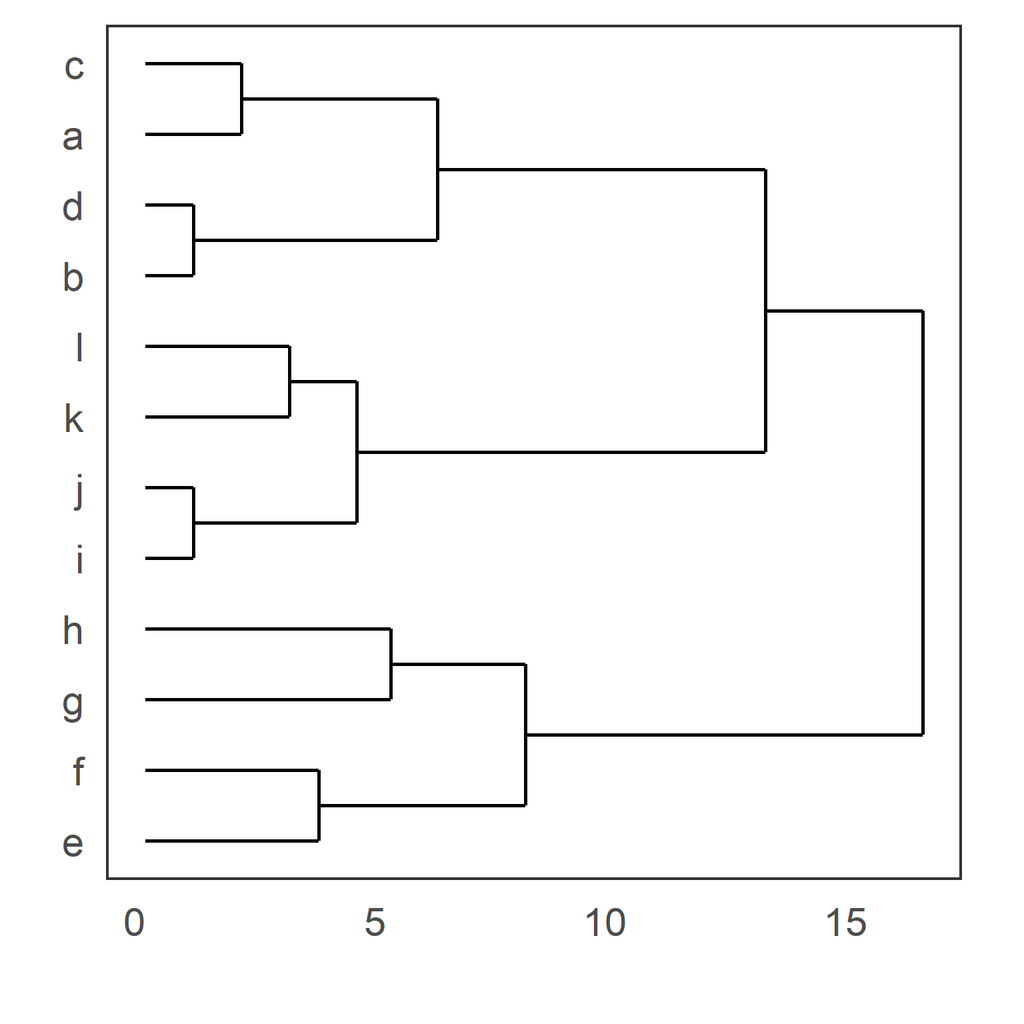

```r
df_hc <- hclust(as.dist(d), method="average")
ggdendrogram(df_hc, rotate = TRUE, size = 4)
```

## Linkage

What is the distance between the new cluster (d,b) and all of the other observations?

Between points in the cluster to points not in the cluster.

- Single: minimum distance between points in the different clusters
- Complete: maximum distance between points in the different clusters
- Average: average of distances between points in the different clusters
- Centroid: distances between the average of the different clusters
- Wards: minimizes the total within-cluster variance

## Linkage

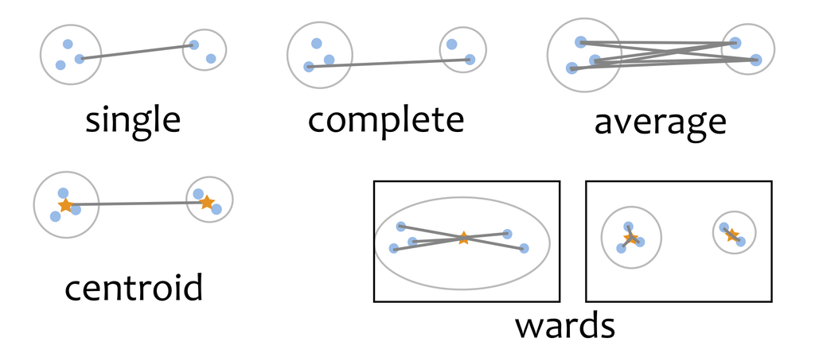

## Calculations with different linkage choices

|  | a | b | c | d | e | f | g | h | i | j | k | l |
| --- | --- | --- | --- | --- | --- | --- | --- | --- | --- | --- | --- | --- |
| a | 0.0 | 5.0 | 2.0 | 5.8 | 18.0 | 17.5 | 21.9 | 17.8 | 13.2 | 13.3 | 10.2 | 10.0 |
| b | 5.0 | 0.0 | 6.4 | 1.0 | 15.8 | 16.3 | 21.6 | 18.4 | 16.1 | 16.0 | 14.3 | 13.3 |
| c | 2.0 | 6.4 | 0.0 | 7.1 | 17.5 | 16.6 | 20.6 | 16.3 | 11.2 | 11.4 | 8.2 | 8.1 |
| d | 5.8 | 1.0 | 7.1 | 0.0 | 15.0 | 15.6 | 21.1 | 18.0 | 16.3 | 16.1 | 14.8 | 13.6 |
| e | 18.0 | 15.8 | 17.5 | 15.0 | 0.0 | 3.6 | 9.1 | 10.0 | 16.6 | 15.7 | 19.4 | 16.5 |
| f | 17.5 | 16.3 | 16.6 | 15.6 | 3.6 | 0.0 | 6.1 | 6.4 | 13.6 | 12.6 | 17.0 | 14.0 |
| g | 21.9 | 21.6 | 20.6 | 21.1 | 9.1 | 6.1 | 0.0 | 5.1 | 14.1 | 13.2 | 18.7 | 15.8 |
| h | 17.8 | 18.4 | 16.3 | 18.0 | 10.0 | 6.4 | 5.1 | 0.0 | 9.1 | 8.1 | 13.6 | 10.8 |
| i | 13.2 | 16.1 | 11.2 | 16.3 | 16.6 | 13.6 | 14.1 | 9.1 | 0.0 | 1.0 | 5.0 | 3.2 |
| j | 13.3 | 16.0 | 11.4 | 16.1 | 15.7 | 12.6 | 13.2 | 8.1 | 1.0 | 0.0 | 5.8 | 3.6 |
| k | 10.2 | 14.3 | 8.2 | 14.8 | 19.4 | 17.0 | 18.7 | 13.6 | 5.0 | 5.8 | 0.0 | 3.0 |
| l | 10.0 | 13.3 | 8.1 | 13.6 | 16.5 | 14.0 | 15.8 | 10.8 | 3.2 | 3.6 | 3.0 | 0.0 |

$a\mapsto b$ = 5  
$a\mapsto b$ = 5.8  
$c\mapsto b$ = 6.4  
$c\mapsto b$ = 7.1

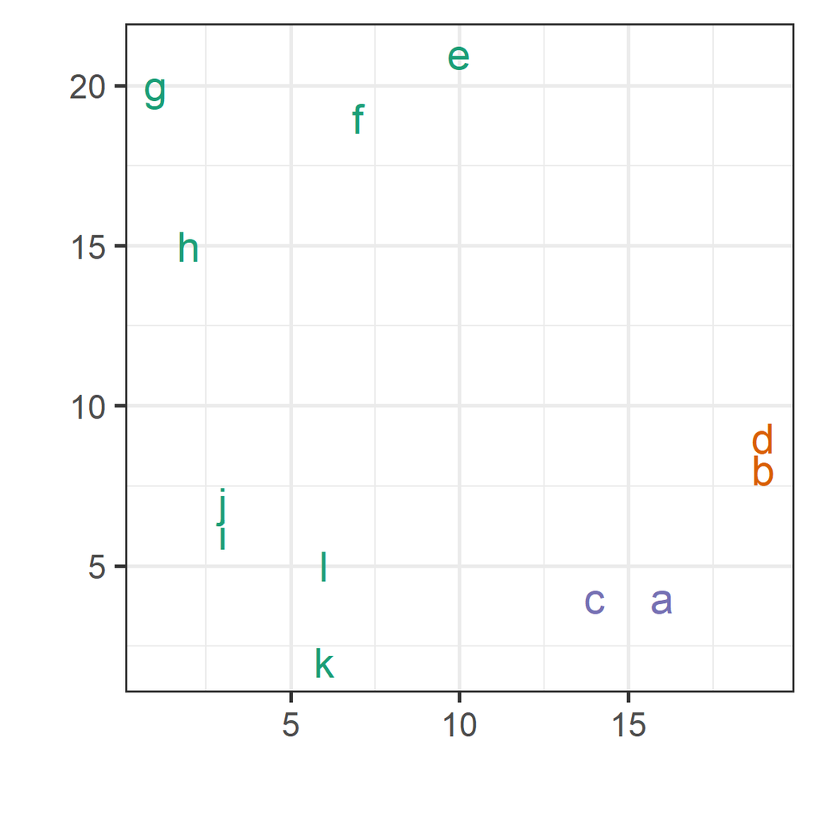

Linkage between (b,d) and (a,c)

Single: $min(a\mapsto b, a\mapsto b, c\mapsto b, c\mapsto b)$  
Complete: $max(a\mapsto b, a\mapsto b, c\mapsto b, c\mapsto b)$  
Average: $mean(a\mapsto b, a\mapsto b, c\mapsto b, c\mapsto b)$  
Centroid: $(\frac{1}{2}(a+c)\mapsto \frac{1}{2}(b+c))$

## Results from different linkage choices

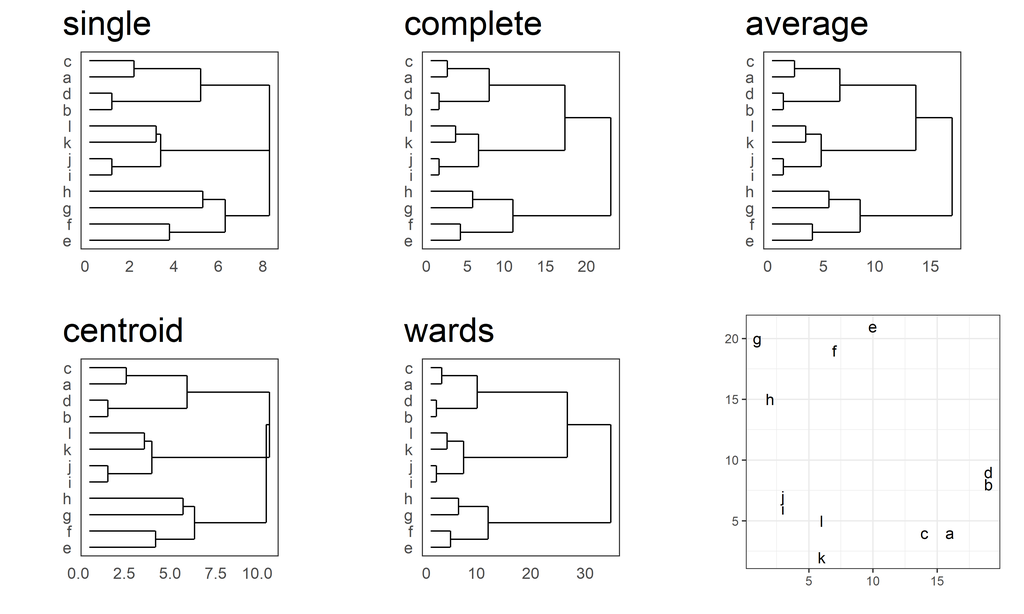

## Dendrogram

- Each leaf of the dendrogram represents one observation
- Leaves fuse into branches and branches fuse, either with leaves or other branches.
- Fusions lower in the tree mean the groups of observations are more similar to each other.

Cut the tree to partition the data into $k$ clusters.

Look for large distances between fusions to estimate the number of clusters

## Cutting the Tree

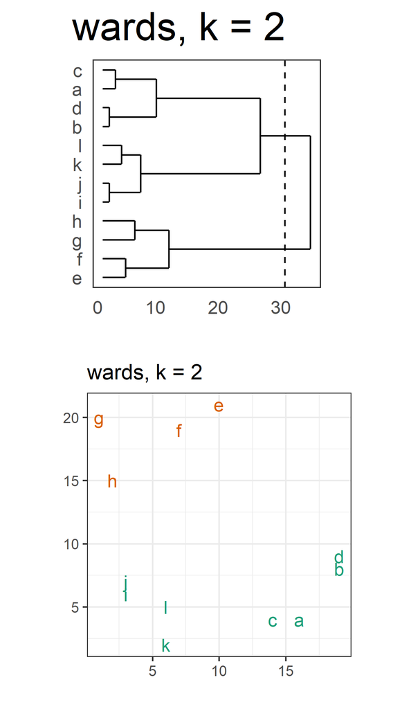

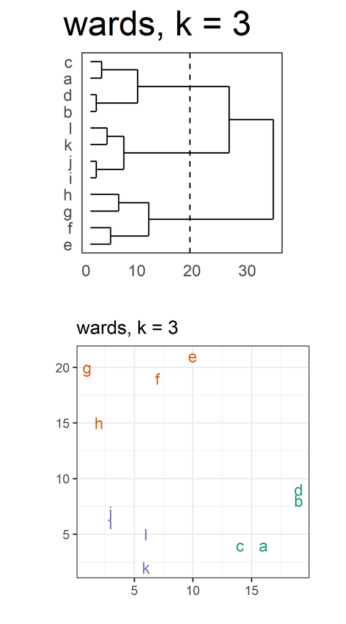

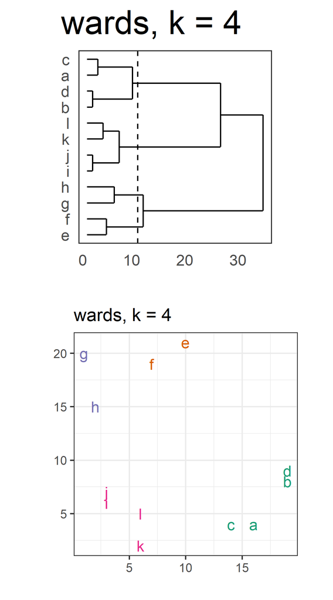

## Results from different linkage choices

*Model-in-the-data-space*

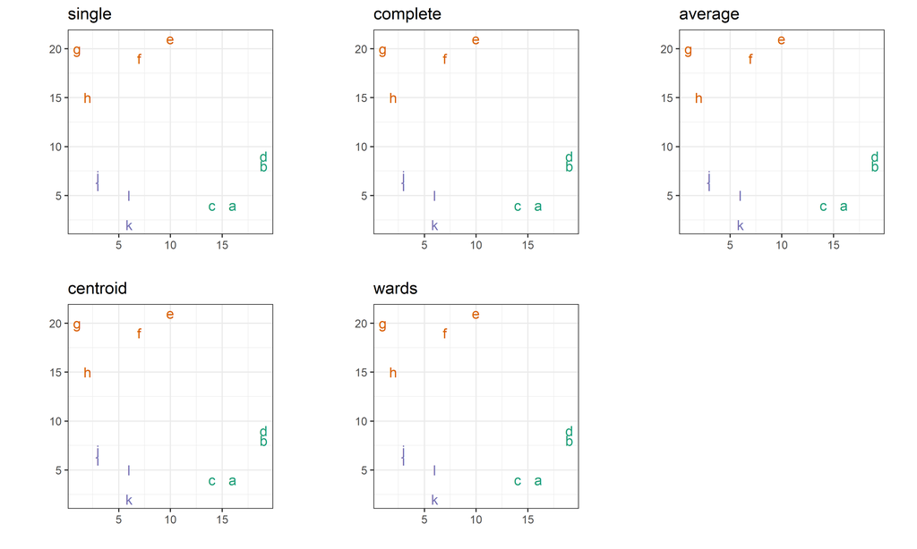

## Example: penguins

- We know there are three clusters, but generally we don’t know this.
- Will $k=3$-means clustering see the clusters that we knoew the data has?
- Fit for various values of $k$. Add cluster label to data.
- Examine solution in plots of the data.
- Compute cluster metrics.
- NOTE: No need for `set.seed()` because results are deterministic.

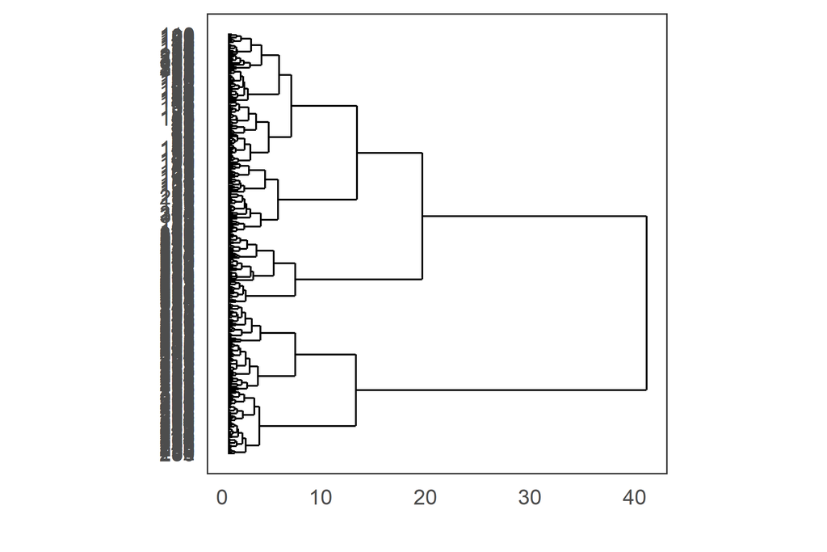

```r
p_hc_w3 <- hclust(dist(p_std[,2:5]), method="ward.D2")

ggdendrogram(p_hc_w3, rotate = TRUE, size = 4)
```

## Example: penguins

```r
p_std_hc_w3 <- p_std |>
  mutate(cl = factor(cutree(p_hc_w3, 3)))
```

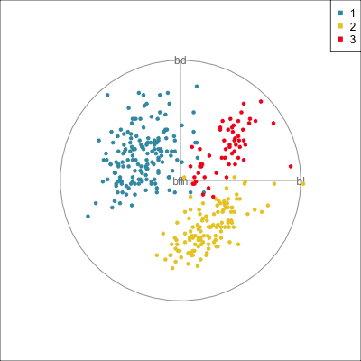

## Choosing $k$ with cluster statistics

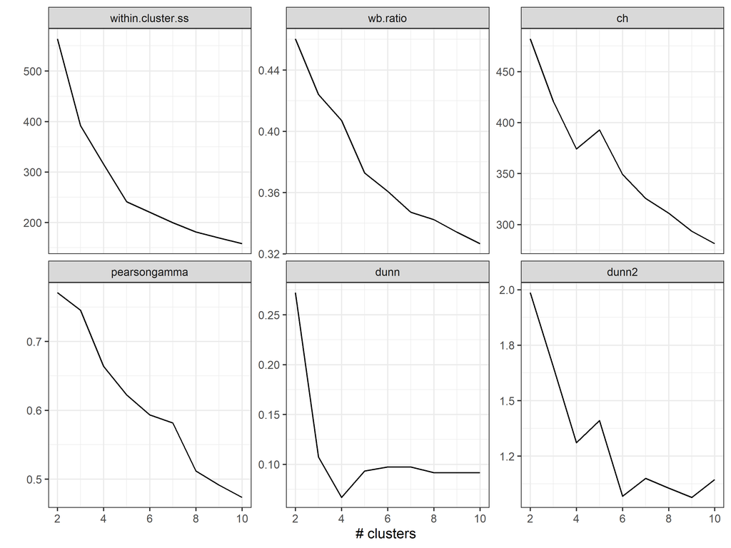

- `within.cluster.ss` and `wb.ratio` suggest 3, and 5
- `pearsongamma` (Hubert) suggests 2-3
- `dunn`, `dunn2`, `ch` all 2?

## Next: Model-based clustering and self-organising maps

ETC3250/5250 Lecture 9